# Prudential Data Wrangling

Francia Moscoso

May 2, 2016

**Loading Libraries**

```r
library(dplyr)
library(corrplot)
library(Amelia)
```

**Populate NA with median values**

```r
Populate_na <- function(datafra)
{
    for(i in 1:ncol(datafra))
    {
        if(is.numeric(datafra[,i]))
        {
            datafra[is.na(datafra[,i]),i] <- median(datafra[!is.na(datafra[,i]),i])
        }
    }
    datafra
}
```

**Loading Data Sets**

```r
# Working Directory
setwd("~/SprintboardProject/PrudentialIns")

# Load raw data to 'train' and 'test' repositories
train <- read.csv("./DataSets/train.csv", header = TRUE)
test <-  read.csv("./DataSets/test.csv", header = TRUE)
```

**Read training data set dimension**

```r
dim(train)
```

```
[1] 59381   128
```

**Evaluate missing data**

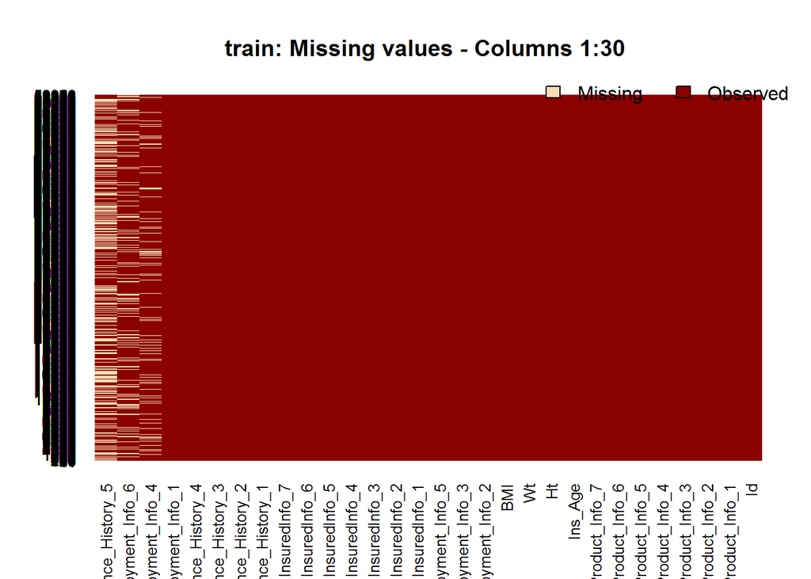

```r
#missmap(train, main = "Missing values vs observed")  All Variables

#Checking train data set missing values
missmap(subset(train,select=c(1:30)),    main = "train: Missing values - Columns 1:30 ")
```

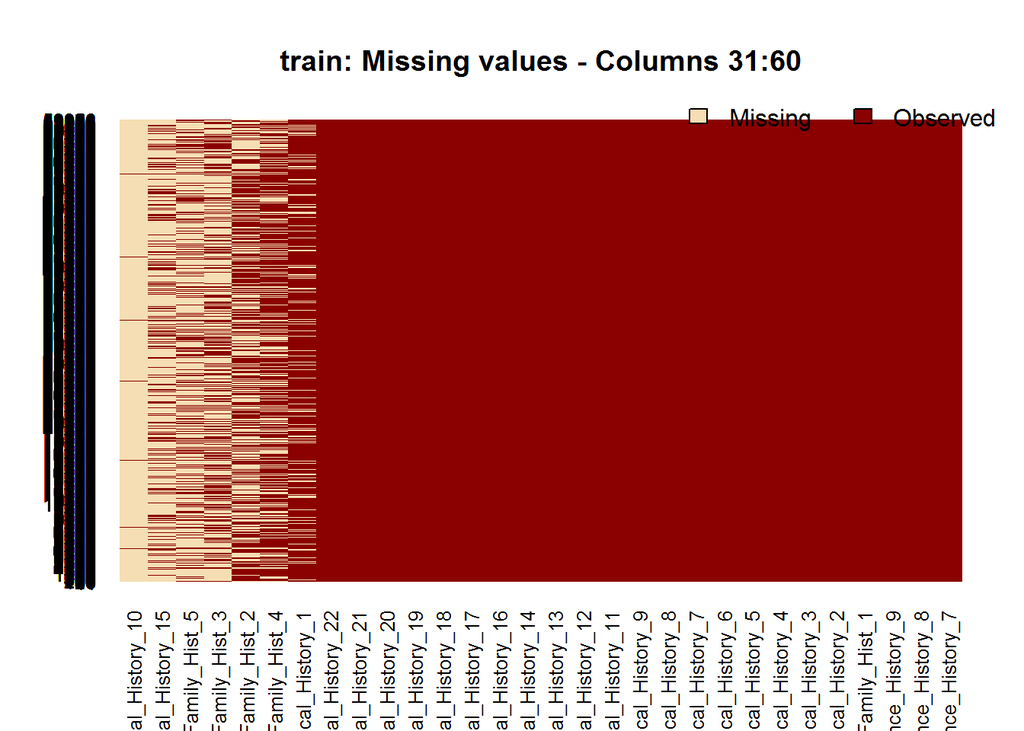

```r
missmap(subset(train,select=c(31:60)),   main = "train: Missing values - Columns 31:60")
```

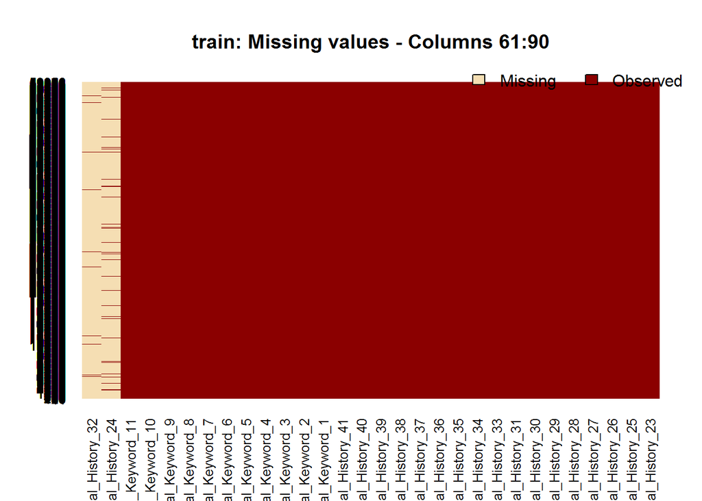

```r
missmap(subset(train,select=c(61:90)),   main = "train: Missing values - Columns 61:90")
```

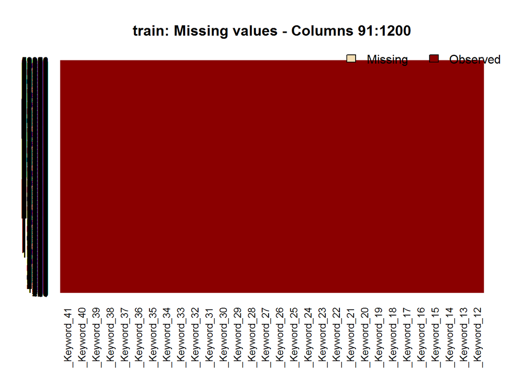

```r
missmap(subset(train,select=c(91:120)),  main = "train: Missing values - Columns 91:1200")
```

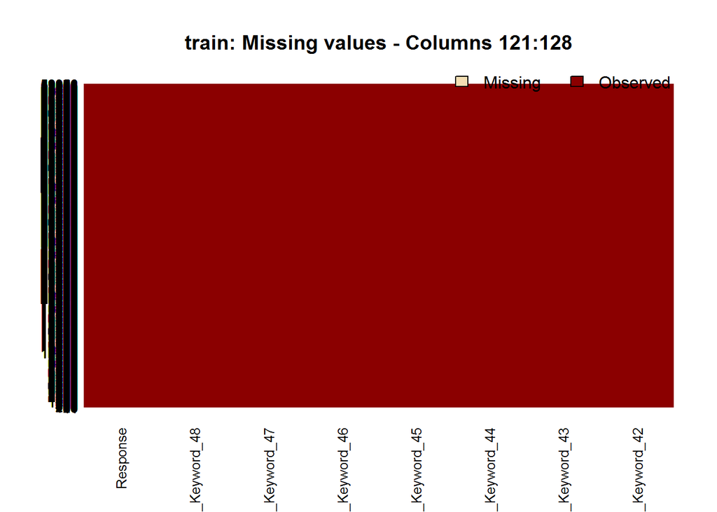

```r
missmap(subset(train,select=c(121:128)), main = "train: Missing values - Columns 121:128")
```

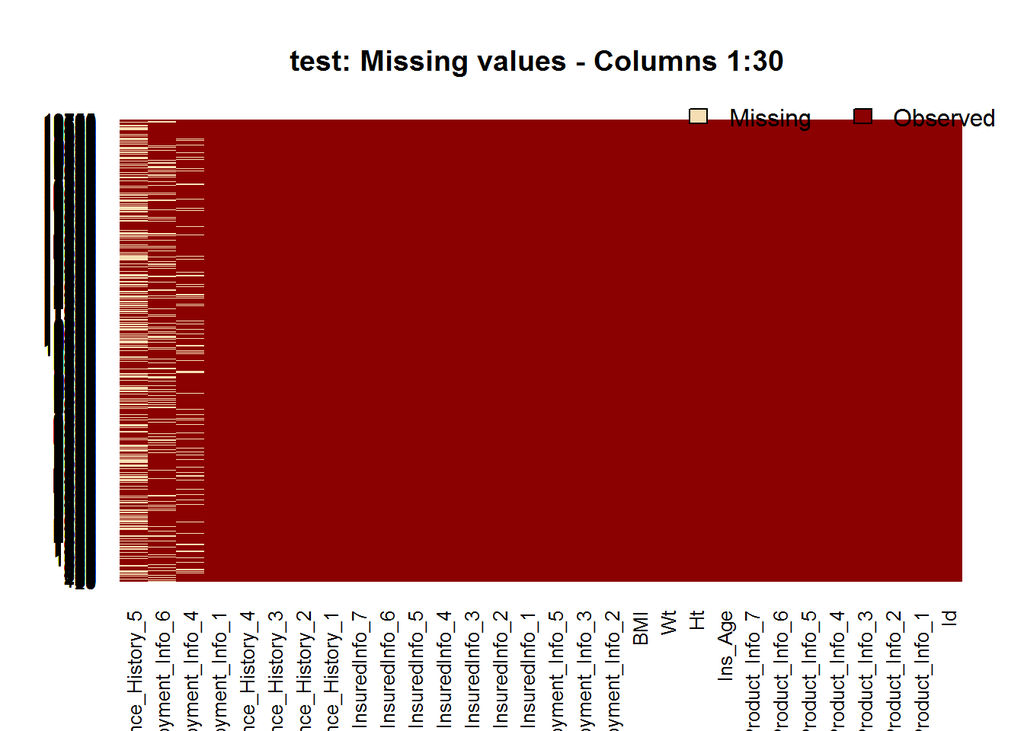

```r
#Checking test data set missing values
missmap(subset(test,select=c(1:30)),    main = "test: Missing values - Columns 1:30 ")
```

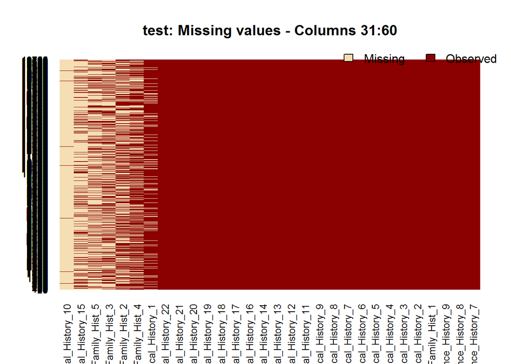

```r
missmap(subset(test,select=c(31:60)),   main = "test: Missing values - Columns 31:60")
```

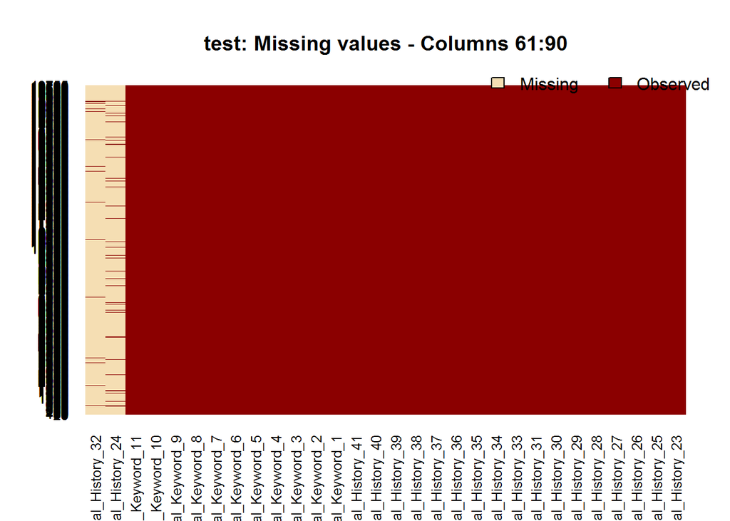

```r
missmap(subset(test,select=c(61:90)),   main = "test: Missing values - Columns 61:90")
```

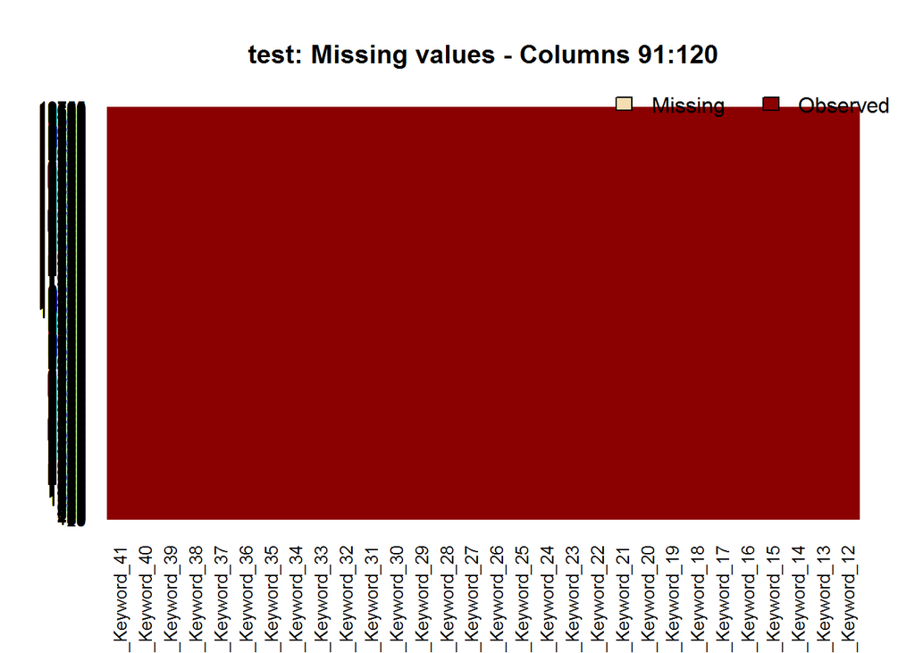

```r
missmap(subset(test,select=c(91:120)),  main = "test: Missing values - Columns 91:120")
```

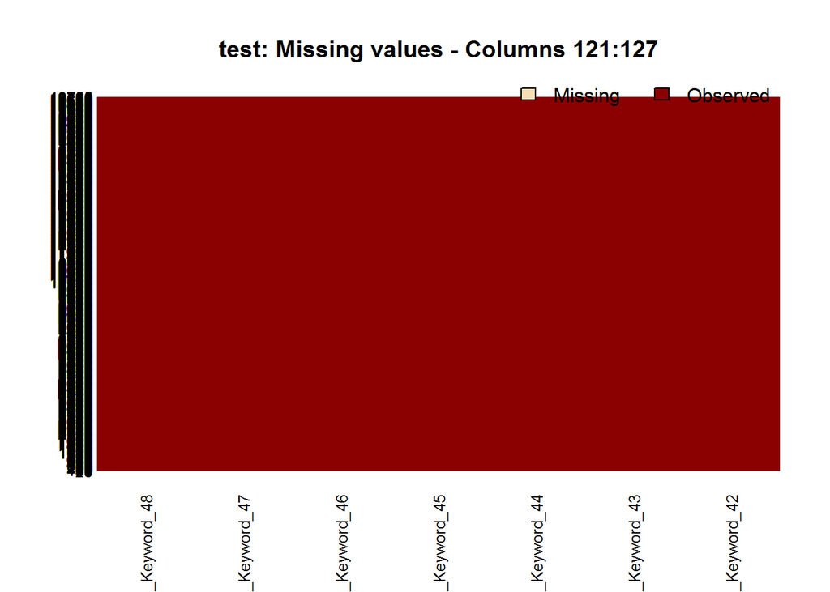

```r
missmap(subset(test,select=c(121:127)), main = "test: Missing values - Columns 121:127")
```

**Percentage of missing data in train data set**

```r
#Number of rows in training data set
TotRow <- nrow(train)

train %>% filter(is.na(Insurance_History_5)) %>% count()/TotRow
```

```
          n
1 0.4276789
```

```r
train %>% filter(is.na(Family_Hist_2)) %>% count()/TotRow
```

```
          n
1 0.4825786
```

```r
train %>% filter(is.na(Family_Hist_3)) %>% count()/TotRow
```

```
          n
1 0.5766323
```

```r
train %>% filter(is.na(Family_Hist_4)) %>% count()/TotRow
```

```
          n
1 0.3230663
```

```r
train %>% filter(is.na(Family_Hist_5)) %>% count()/TotRow
```

```
          n
1 0.7041141
```

```r
train %>% filter(is.na(Medical_History_1)) %>% count()/TotRow
```

```
          n
1 0.1496943
```

```r
train %>% filter(is.na(Medical_History_10)) %>% count()/TotRow
```

```
          n
1 0.9906199
```

```r
train %>% filter(is.na(Medical_History_15)) %>% count()/TotRow
```

```
          n
1 0.7510146
```

```r
train %>% filter(is.na(Medical_History_24)) %>% count()/TotRow
```

```
          n
1 0.9359896
```

```r
train %>% filter(is.na(Medical_History_32)) %>% count()/TotRow
```

```
          n
1 0.9813577
```

**The following train data set columns have missing data in a percentage greater than 30%:**  
Insurance_History_5 (42.76%)  
Family_Hist_2(48.25%)  
Family_Hist_3(57.66%)  
Family_Hist_4(32.30%)  
Family_Hist_5(70.41)  
Medical_History_10(99.06%)  
Medical_History_15(75.10%)  
Medical_History_24(93.59%)  
Medical_History_32(98.13%)  
**Percentage of missing data in test data set**

```r
#Number of rows in training data set
TotRow <- nrow(test)

test %>% filter(is.na(Insurance_History_5)) %>% count()/TotRow
```

```
          n
1 0.4100683
```

```r
test %>% filter(is.na(Employment_Info_4)) %>% count()/TotRow
```

```
          n
1 0.1081204
```

```r
test %>% filter(is.na(Employment_Info_6)) %>% count()/TotRow
```

```
          n
1 0.1916013
```

```r
test %>% filter(is.na(Family_Hist_2)) %>% count()/TotRow
```

```
          n
1 0.4998735
```

```r
test %>% filter(is.na(Family_Hist_3)) %>% count()/TotRow
```

```
          n
1 0.5597774
```

```r
test %>% filter(is.na(Family_Hist_4)) %>% count()/TotRow
```

```
          n
1 0.3378194
```

```r
test %>% filter(is.na(Family_Hist_5)) %>% count()/TotRow
```

```
          n
1 0.6892993
```

```r
test %>% filter(is.na(Medical_History_1)) %>% count()/TotRow
```

```
          n
1 0.1503668
```

```r
test %>% filter(is.na(Medical_History_10)) %>% count()/TotRow
```

```
          n
1 0.9898305
```

```r
test %>% filter(is.na(Medical_History_15)) %>% count()/TotRow
```

```
          n
1 0.7520364
```

```r
test %>% filter(is.na(Medical_History_24)) %>% count()/TotRow
```

```
          n
1 0.9402985
```

```r
test %>% filter(is.na(Medical_History_32)) %>% count()/TotRow
```

```
          n
1 0.9822413
```

```r
#train data set: Populate missing data with median values - Exclude column: 1 (Id)
tra_clean <- Populate_na(train[,-c(1)])

#test data set: Populate missing data with median values - Exclude column: 1 (Id)
test_clean <- Populate_na(test[,-c(1)])
```